# An investigation on the Financial Determinants of Stock Prices : Predictive Machine Learning Modeling with Evidence from the S&P 500

Timo Büscher, Burak Arslan, Victor Htema

2023-10-31

# 1 Introduction

The 2007-2008 Financial Crisis devastated the world economy beginning with the meltdown in the American sub-prime mortgage market, which due to the excessive borrowing and lending in the previous years provoked panic and sparked a global credit crisis, that further amplified the fall of assets in all sorts of industries in the internationally interlinked markets with the eventual worldwide recession (Arner, 2009). During and after the unfolding crisis, millions of people lost their jobs, especially the younger population (Choudhry et al., 2012), with the long-term effect on the global unemployment level estimated in 2013 to be 60 million higher than the pre-crisis trends predicted (ILO, 2014). Furthermore, a large number of people saw their houses and life savings dwindle in value due to the bursts of the housing and other industries bubbles, with their hedge funds and investment accounts suffering heavy losses due to circumstantial imposed widespread fire sales of assets (Bernanke, 2018). The outcome of the economic fallout led to a surge in the general level of poverty, with the most severely affected countries having to cut significant portions of their budgets on education, healthcare, and social security at a time of utmost necessity for the numerous individuals in distress (Karanikolos et al., 2013). In extreme cases, countries such as Greece and Cyprus saw their economies contract in the next 6 years by around 30 and 10 percent of their GDP (Hermann, 2017), while the OECD countries, which had also suffered a banking crisis as a consequence, had in 2014 a GDP growth trend lower by 5.5 percent than the pre-crisis growth trends predicted (Ollivaud & Turner, 2014). The dire economic conditions in which the young people could not get integrated into the workforce as swiftly as the previous generations had profound social effects, as they failed to take advantage of some of their most productive years and establish the financial fundamentals for their own households (Choudhry et al., 2012), living through the so-called by some economists “Lost decade” (Hermann, 2017). Moreover, all of these factors also partially contributed to the increase in global suicide levels and the spread of mental illnesses in the societies of various nations (Karanikolos et al., 2016)

Naturally, in order to be able to prevent such terrible recessions, governments, economists, and market players have to study thoroughly the flaws of the economic framework and come up with improvements and instruments to safeguard the economies in the future. Institutions, statisticians, and financial analysts have been gathering for decades ever-increasing amounts of data on all sorts of economic subjects and phenomena, which must be processed and interpreted with the most up-to-date data analysis and machine learning techniques to provide elaborate instruments for efficient economic analysis and actions. The focus of this research will investigate one of the paramount factors that exacerbated and subsequently also caused the 2007-2008 Financial Crisis, which was the failure of the market participants’ evaluation methods to offer accurate and rigorous estimates of the real value of companies, causing chaos and uncertainty among the ranks of the financial market participants that could no longer trust and deal transactions with their partners, even if the affected firms had otherwise sound balance sheets (Bernanke, 2018). Thus, at the height of the crisis, the freezing of the liquidity of the whole credit market commenced, leaving numerous potential business projects and companies in need of liquid assets without any investment source, which consequently led to significant capital losses in the economy and the bankruptcy of numerous firms with the notable case of Lehman Brothers investment bank filing for the highest bankruptcy in history with 680 billion dollars in assets and 100,000 creditors (Arner, 2009).

Therefore, in order to provide an accessible framework for the analysis of stock prices, this paper states the following research question: **‘To what degree do various financial variables aid in the prediction of stock prices?’**

For this research, a data set is going to be used, containing raw data of the most important financial metrics of the companies listed in the S&P 500 index in the 2020 fiscal year. The S&P 500 firms represent a suitable object of study, as it consists of the biggest companies in diverse industries in the United States, which also has the biggest economy in the world and makes it automatically an example to be followed by all the other countries. A 6-Step extensive data analysis strategy will be employed with the appropriate data science methods in order to better understand the data set and investigate the research question. After the Research Understanding introductory phase, Datat preparation of the given dataset will be conducted, and then the investigation of the variables of significance in the Exploratory Data Analysis phase will take place. Thereafter, the appropriate models and algorithms will be utilized to test the research hypotheses and interpret their usefulness in the Modeling and Evaluation stages, with the corresponding final conclusion.

To complement the analysis, following R libraries will be used throughout the research:

- `plyr`: package that is applied when summarizing the data frame and working on data manipulations
- `dplyr`: package that is applied when summarizing the data frame and working on data manipulations
- `ggplot2`: package that contains functions to visuialize data in **R**
- `naniar`: package that is utilized to plot and impute missing values
- `Hmisc`: package that is used to impute missing values
- `liver`: package that contains functions that is utilized to partition data and calculate the mean squared error (MSE)
- `rpart`: package that is utilized to partition the data into train and test
- `rpart.plot`: package that plots a decision tree for the `CART` algorithm
- `randomForest`: package that contains functions that are used to implement the Random Forest algorithm
- `psych`: package that provides functions for correlation analysis
- `ggcorrplot`: package that is utilized to visualize correlation matrix
- `GGally`: package that is utilized to plot the pairwise correlation matrix

```r
library(plyr)
library(dplyr)
library(ggplot2)
library(naniar)
library(Hmisc)
library(liver)
library(rpart)
library(rpart.plot)
library(randomForest)
library(psych)
library(ggcorrplot)
library(GGally)
```

# 2 Theoretical Framework

## 2.1 The ability of stock price prediction

A stock index is a collection of equities or securities, which is normally computed from the market capital of constituents. As such, the S&P 500 stock index provides a summary of the overall market performance of the US and helps its investors in their investing activities. It is the most widely used benchmark for measuring the performance of US-based stocks, as it constitutes around 83 % of the market capitalization of all regularly traded stocks on the New York, American, and NASDAQ exchanges, and covers almost all of the 500 largest companies ranked by market value (Siegel & Schwartz, 2006). Consequently, the prediction of such a stock index is of high importance.

Research proves that the ability of companies to predict stock prices is a crucial and complex endeavor for stock companies, policy-makers, and investors alike (Bekiros et al., 2016). This is because accurate stock price predictions enable the ability to make informed investment decisions, informed risk management, and enhanced financial performance (Wang, 2014). The leading example, which demonstrates the need for data-driven investment strategies is the illusion of the long-lasting Efficient Market Hypothesis, through which it is proposed that the pricing of the markets is efficient and all the available information is reflected in the prices (Fama, 1970). Meanwhile, financial crises such as the one in 2008, prove that investors are not always rational, and even by obtaining perfect information, investment strategies might not be optimal due to emotional barriers (Ying et al., 2019). As such, taking into account both the favor and criticism of the Efficient Market Hypothesis, it can be claimed that the information can either be reflected in the prices or not (Malkiel, 2003). Since there is no proven consensus on price prediction strategies given the recent turmoil in the financial theory, conventional models that use financial information are expected to correctly predict the stock prices at 50% of the time or more which is no significantly different prediction value of simple random chance. The research models will merely use the financial information to test whether the financial information will present statistical significance in predicting stock prices by being in favor of the Efficient Market Hypothesis.

Following this realization, the main hypothesis of this research can be constructed:

**H1**: The proportion of companies that are correctly predicted for their future stock prices is more than 50%.

## 2.2 Financial Determinants of Price

Considering the previous disastrous impacts of the financial crises in the near history, it became evident that institutions and companies created their own ways in predicting stock prices. Even though the strategies use various statistical and financial techniques, there is a financial theory presented that stock prices are influenced by a wide range of financial information, which collectively reflects the health and performance of a company. This information usually comes in the form of financial ratios and inputs in the financial statements of the company. By presenting the summary of the reasons and the current situation in predicting stock prices, the theoretical background of the 4 main determinants of stock prices will be observed and necessary hypotheses will be stated.

### 2.2.1 Dividend and Dividend Yield

The neoclassical school of economic thought theorized that companies essentially aim to maximize profits (Mulligan, 1986). The general motivation of the theory is to redistribute a portion of profits to the company’s shareholders in the form of dividends. In this sense, paying dividends serves a common purpose which is to attract more investors to the company by offering them a stable return in the long run (Feldstein and Green, 1983). Consequently, just like companies, individuals are also motivated by maximizing profits where investors are more likely to buy stocks with higher dividend yield where on the contrary investments might not be considered with no dividend income (Friends and Puckett, 1964). Furthermore, there is substantial econometric evidence that hoarding cash can be value reducing for companies in the long run due to inefficient allocation of capital (Denis and Sibilkov, 2010). Overall, dividend payouts are a way to signal the financial performance of the company as well as maintaining constant enhancement for investments. The aforementioned reasons about dividend payments and yields can boost up the demand for stocks which in turn pushes up the stock price. Therefore, the following hypotheses are constructed:

**H2a**: Companies that pay dividends have a higher price prediction compared to the companies that do not pay dividends.

**H2b**: Companies that have a higher dividend yield have a higher price prediction compared to the companies that do not pay dividends.

### 2.2.2 Earnings Per Share and Sectors

Another financial metric that is presented in the quarterly financial statements of the companies which is an indication of the company’s profitability for every share the company is divided to. The EPS itself is forecasted by analysts to create expectations in the market where higher than expected EPS growth brings positive investor sentiment which increases the stock prices (Lander et al., 1997). The increase in demand is explained in another research where the study showed that investors tend to show a bias towards future growth in EPS by judging past expectations (de Wet, 2013). However, there is also contrasting research where evidence suggests that EPS and stock prices do not always go in the same direction mainly due to macroeconomic risks and company related effects (Islam et al., 2014). As stock prices reflect a future potential on earnings, the ratio may show differentiations based on the sector that the company is operating in since some sectors are profitable in certain conditions. For instance, the earnings for the healthcare sector excessed other sectors during the COVID pandemic due to developments of vaccines and treatments (Esparcia and López, 2022). On the other hand, as the outside conditions are subject to change and every sector presents its own advantages, sector profitability presents cyclicality which may not be consistent. However, due to the added value of some specific sectors, such as the difference between the products of technology and consumer discretionary sectors, the effects of sectors are thought of to be relevant. Considering the overview, it can be seen that even though EPS is not sufficient by itself to determine financial health, it still is a valid metric to signal profit expectations of a company. Thus, the following hypothesis is stated:

**H2c**: Companies that have a higher earnings per share ratio have a higher price prediction compared to companies that have a lower earnings per share

**H2d**: The sector of the companies have no effect on the stock price.

### 2.2.3 Price Sales and Price Book Ratio

Price Sales and Price Book ratios are essential valuations metrics that combine the relationship between the market value of a stock and the inherent value of the company’s financials. Price sales ratio indicates how much investors are willing to pay for each dollar of sales (Vruwink et al., 2007) and it is calculated through dividing the market cap by total revenue. A way to interpret the P/S ratio is to understand its fluctuations where a higher ratio means that buyers are willing to pay more for the stock compared to the companies that generate the same revenue. However, there is also consensus in the theory that high P/S companies are classified as overvalued and may have downward price pressure for their stock in the long run (Danielson and Lipton, 2015).

On the other hand, the price book ratio presents a company’s market cap to its book value where it signals the value per share that the investors will receive in case of liquidation of the company. The ratio is utilized to assess the valuation of market price to compare with its intrinsic value where previous research argued that if the ratio is deep above or below 1 it is a signal for overvaluation or undervaluation respectively (Bernard, 1994). Therefore, the econometric evidence showed that the price-book ratio explains the price variances at 66% of the time along with ROE (Bernard, 1994). Furthermore, there is also valid criticism as book value does not take into account intangible assets, it is not a reliable indicator for non-capital intensive companies (Berk and DeMarzo, 2019). Thus, for certain companies price book ratio is not as significant in determining the stock price as price sales ratio. The findings in the previous literature and theory suggest that higher price sales ratio tend to boost up valuations and expectations whereas higher price book ratio signals overvaluation and breaks up demand for the stock. Taking into account the background knowledge, following hypotheses will be tested.

**H2e**: Companies with higher price-sales ratio have a higher price prediction compared to companies with low price-sales ratio.

**H2f**: Companies with lower price-book ratio have a higher price prediction compared to companies with high price-sales ratio.

# 3 Data Preprocessing

The raw data is gathered using Kaggle that is an online community for data science contents where various datasets on a wide range of topics are present. The metadata presents that the dataset is constructed by a Kaggle collaborator by utilizing the online data collection center DataHub.io (https://datahub.io/) which is gathered using the data from July 2020. In this sense, besides the financial information, the raw data also includes the SEC filings for all companies in order for the financial information to be verified that shows the validity of the dataset even though the column with the links are deleted for the sake of the econometric analysis. Besides that, a dummy variable called `Dividend` is created manually if the `Dividend.Yield` is different than 0. A dummy variable of `PositiveEBITDA` is also created that gets a value of 1 if the company has positive earnings which may have an affect on the price that lays the foundations of the data collection methodology. Finally, the reason for the selection of S&P 500 index rather than the others is because it contains the largest 505 public companies in the US which indicates an overall economic health. The following link directs to the dataset which ensures the replicability of the research: https://www.kaggle.com/datasets/paytonfisher/sp-500-companies-with-financial-information/data

Before conducting a statistical analysis and create a predictive model, the components of the dataset are investigated thoroughly. The csv file is imported to *R*.

```r
financial_data <- read.csv("C:/Users/Burak/OneDrive/Desktop/financials.csv")

financial_data<-financial_data  %>%
  mutate(Dividend = ifelse(Dividend.Yield > 0, "Yes", "No" ))
financial_data<-financial_data %>%
  mutate(Dividend.Binary = ifelse(Dividend.Yield > 0, 1, 0))


financial_data<-financial_data  %>%
  mutate(PositiveEBITDA = ifelse(EBITDA > 0, "Yes", "No"))
financial_data<-financial_data  %>%
  mutate(PositiveEBITDA.Binary = ifelse(EBITDA > 0, 1, 0))


financial_data <- within(financial_data, rm(Symbol, SEC.Filings))
```

```r
financial_data <- dplyr::rename(financial_data, c("X52.Week.Low" = "X52.Week.High"), c("X52.Week.High" = "X52.Week.Low"))
```

In order to observe the internal structure of the dataset and the objects, `str()` function is used:

```r
str(financial_data)
```

```
  'data.frame': 505 obs. of  16 variables:
   $ Name                 : chr  "3M Company" "A.O. Smith Corp" "Abbott Laboratories" "AbbVie Inc." ...
   $ Sector               : chr  "Industrials" "Industrials" "Health Care" "Health Care" ...
   $ Price                : num  222.9 60.2 56.3 108.5 150.5 ...
   $ Price.Earnings       : num  24.3 27.8 22.5 19.4 25.5 ...
   $ Dividend.Yield       : num  2.33 1.15 1.91 2.5 1.71 ...
   $ Earnings.Share       : num  7.92 1.7 0.26 3.29 5.44 1.28 7.43 3.39 6.19 0.03 ...
   $ X52.Week.High        : num  259.8 68.4 64.6 125.9 162.6 ...
   $ X52.Week.Low         : num  175.5 48.9 42.3 60 114.8 ...
   $ Market.Cap           : num  1.39e+11 1.08e+10 1.02e+11 1.81e+11 9.88e+10 ...
   $ EBITDA               : num  9.05e+09 6.01e+08 5.74e+09 1.03e+10 5.64e+09 ...
   $ Price.Sales          : num  4.39 3.58 3.74 6.29 2.6 ...
   $ Price.Book           : num  11.34 6.35 3.19 26.14 10.62 ...
   $ Dividend             : chr  "Yes" "Yes" "Yes" "Yes" ...
   $ Dividend.Binary      : num  1 1 1 1 1 1 1 0 1 0 ...
   $ PositiveEBITDA       : chr  "Yes" "Yes" "Yes" "Yes" ...
   $ PositiveEBITDA.Binary: num  1 1 1 1 1 1 1 1 1 1 ...
```

Finally, it is important to note that the variables `Dividend.Binary` and `PositiveEBITDA.Binary` are only used in the Exploratory Data Analysis section to ease the analysis which transforms the binary characters of **Yes** and **No** to integer values of **1** and **0**.

Considering the interpretation of each variable, the initial section of the dataframe is presented by using the `head()` function to have a clear understanding.

```r
head(financial_data)
```

```
                   Name                 Sector  Price Price.Earnings
  1          3M Company            Industrials 222.89          24.31
  2     A.O. Smith Corp            Industrials  60.24          27.76
  3 Abbott Laboratories            Health Care  56.27          22.51
  4         AbbVie Inc.            Health Care 108.48          19.41
  5       Accenture plc Information Technology 150.51          25.47
  6 Activision Blizzard Information Technology  65.83          31.80
    Dividend.Yield Earnings.Share X52.Week.High X52.Week.Low   Market.Cap
  1      2.3328617           7.92       259.770      175.490 138721055226
  2      1.1479592           1.70        68.390       48.925  10783419933
  3      1.9089824           0.26        64.600       42.280 102121042306
  4      2.4995599           3.29       125.860       60.050 181386347059
  5      1.7144699           5.44       162.600      114.820  98765855553
  6      0.4319032           1.28        74.945       38.930  52518668144
         EBITDA Price.Sales Price.Book Dividend Dividend.Binary PositiveEBITDA
  1  9048000000    4.390271      11.34      Yes               1            Yes
  2   601000000    3.575483       6.35      Yes               1            Yes
  3  5744000000    3.740480       3.19      Yes               1            Yes
  4 10310000000    6.291571      26.14      Yes               1            Yes
  5  5643228000    2.604117      10.62      Yes               1            Yes
  6  2704000000   10.595120       5.16      Yes               1            Yes
    PositiveEBITDA.Binary
  1                     1
  2                     1
  3                     1
  4                     1
  5                     1
  6                     1
```

In this regard, `summary()` function is used to summarize the dataframe and the characteristics of the variables.

```r
summary(financial_data)
```

```
       Name              Sector              Price         Price.Earnings
   Length:505         Length:505         Min.   :   2.82   Min.   :-251.53
   Class :character   Class :character   1st Qu.:  46.25   1st Qu.:  15.35
   Mode  :character   Mode  :character   Median :  73.92   Median :  19.45
                                         Mean   : 103.83   Mean   :  24.81
                                         3rd Qu.: 116.54   3rd Qu.:  25.75
                                         Max.   :1806.06   Max.   : 520.15
                                                           NA's   :2
   Dividend.Yield    Earnings.Share    X52.Week.High      X52.Week.Low
   Min.   : 0.0000   Min.   :-28.010   Min.   :   6.59   Min.   :   2.80
   1st Qu.: 0.7948   1st Qu.:  1.490   1st Qu.:  56.25   1st Qu.:  38.43
   Median : 1.7693   Median :  2.890   Median :  86.68   Median :  62.85
   Mean   : 1.8960   Mean   :  3.754   Mean   : 122.62   Mean   :  83.54
   3rd Qu.: 2.7811   3rd Qu.:  5.140   3rd Qu.: 140.13   3rd Qu.:  96.66
   Max.   :12.6612   Max.   : 44.090   Max.   :2067.99   Max.   :1589.00

     Market.Cap            EBITDA            Price.Sales        Price.Book
   Min.   :2.626e+09   Min.   :-5.067e+09   Min.   : 0.1532   Min.   :   0.51
   1st Qu.:1.273e+10   1st Qu.: 7.739e+08   1st Qu.: 1.6295   1st Qu.:   2.02
   Median :2.140e+10   Median : 1.614e+09   Median : 2.8964   Median :   3.40
   Mean   :4.924e+10   Mean   : 3.590e+09   Mean   : 3.9417   Mean   :  14.45
   3rd Qu.:4.512e+10   3rd Qu.: 3.693e+09   3rd Qu.: 4.7038   3rd Qu.:   6.11
   Max.   :8.095e+11   Max.   : 7.939e+10   Max.   :20.0943   Max.   :1403.38
                                                              NA's   :8
     Dividend         Dividend.Binary  PositiveEBITDA     PositiveEBITDA.Binary
   Length:505         Min.   :0.0000   Length:505         Min.   :0.0000
   Class :character   1st Qu.:1.0000   Class :character   1st Qu.:1.0000
   Mode  :character   Median :1.0000   Mode  :character   Median :1.0000
                      Mean   :0.8297                      Mean   :0.8673
                      3rd Qu.:1.0000                      3rd Qu.:1.0000
                      Max.   :1.0000                      Max.   :1.0000
```

In order to conduct a statistical research, we need to prepare the data set for a proper analysis where the outliers are adjusted and the missing values are handled. In this sense, the data preprocessing stage is essential to obtain a viable trend for the regression analysis and a prediction.

Considering this, the missing values are denoted as NA’s in the summary where the data set contains 8 missing values for the variable `Price.Book` and 2 missing values for the variable `Price.Earnings`.

It is a known fact that the largest companies in the S&P500 index are selected based on their market cap. However, since the market cap is subject to change on a daily basis, it is not a good indicator to capture financial health. Therefore, to indicate outliers in the dataframe, earnings per share as a ratio is used, that not only has a direct affect on market cap but also shows an indication for financial performance which changes less frequently. Thus, in order to capture the outlier companies in the index, we will be observing the `Earnings.Share` variable.

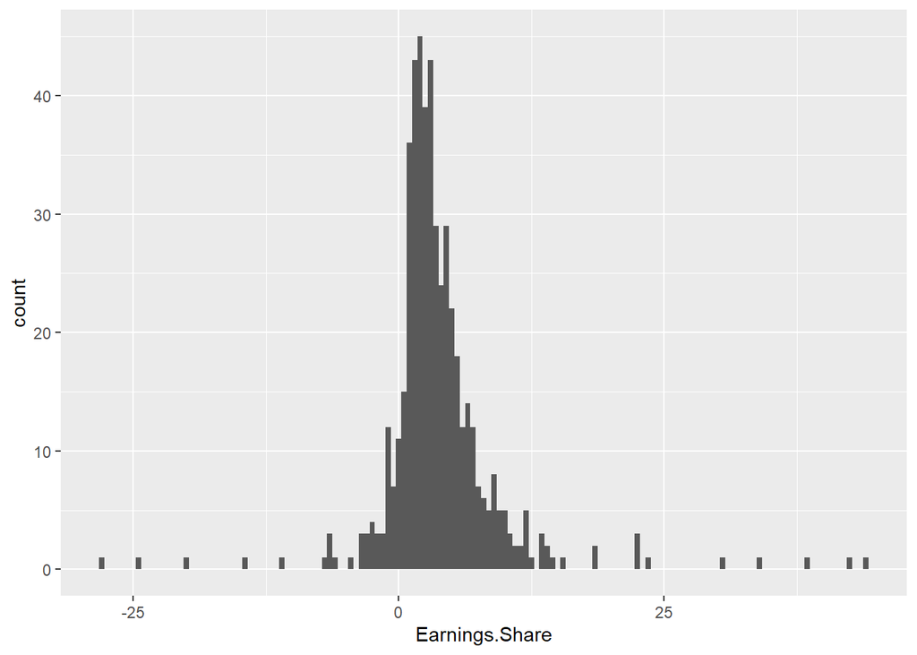

```r
ggplot( data = financial_data ) +
    geom_histogram( aes( x = Earnings.Share ), binwidth = 0.5 )
```

Based on the above output, we observe a bell curve shaped distribution for the Earnings.Share amongst the companies. As the data visualizations are not always clear in showing the trend, a boxplot is created to calculate the outliers.

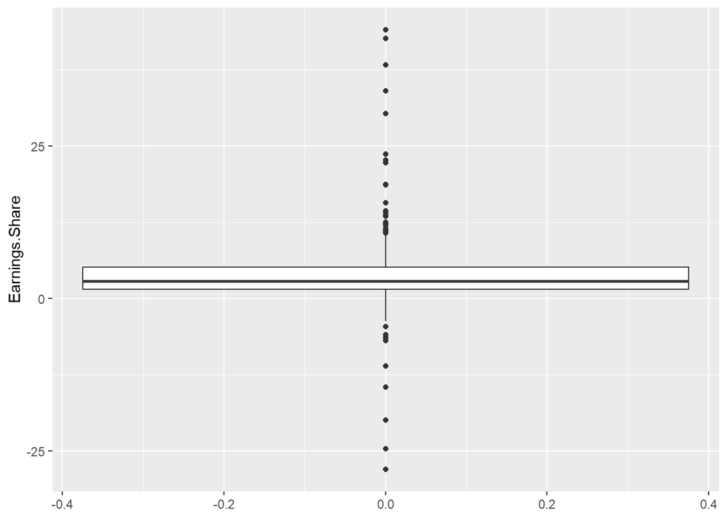

```r
ggplot( data = financial_data, aes( y = Earnings.Share ) ) +
     geom_boxplot()
```

```r
summary(financial_data$Earnings.Share)
```

```
     Min. 1st Qu.  Median    Mean 3rd Qu.    Max.
  -28.010   1.490   2.890   3.754   5.140  44.090
```

All data that is either above the third quartile or below the first quartile by 1.5 times the interquartile range (IQR) is tagged as an outlier treated as is. In this sense, the IQR is the difference between the third and the first quartiles which is 3.65 (5.140 - 1.490). In this sense the upper boundary for outliers is 10.615 and the lower boundary is -3.985. Therefore, the companies that have an earnings per share that is above 10.615 or below -3.985 are considered as outliers. In order to treat outliers, they will be imputed by missing values and will be treated as one.

```r
financial_data_noutliers = mutate( financial_data, Earnings.Share = ifelse(Earnings.Share < -3.985 | Earnings.Share > 10.615, NA, Earnings.Share))
summary(financial_data_noutliers$Earnings.Share)
```

```
     Min. 1st Qu.  Median    Mean 3rd Qu.    Max.    NA's
   -3.720   1.498   2.810   3.178   4.750  10.400      41
```

To check all the missing values in the dataset, the function `gg_missing_var()` is used that is taken from the `naniar` library.

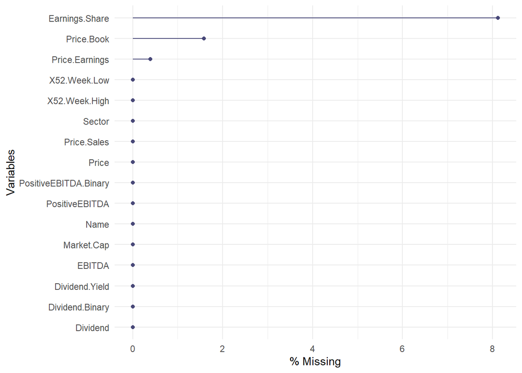

```r
gg_miss_var( financial_data_noutliers, show_pct = TRUE )
```

It can be seen that missing values are contained in the variables `Price.Earnings` and `Price.Book` both of them having less than 2% of missing values. Finally around 8% of the data in the variable `Earning.Share` are missing due to outliers. An essential way to treat missing values is to replace them with random values where the built-in library called `hmisc` is used to call the `impute()` function:

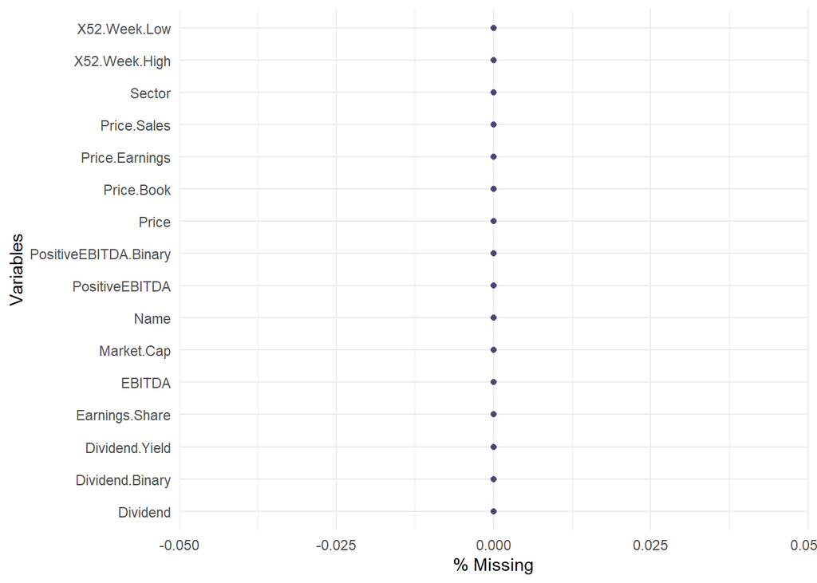

```r
financial_data_noutliers $ Price.Earnings      = impute( financial_data_noutliers $ Price.Earnings     , 'random' )
financial_data_noutliers $ Price.Book          = impute( financial_data_noutliers $ Price.Book, 'random' )
financial_data_noutliers $ Earnings.Share      = impute( financial_data_noutliers $ Earnings.Share    , 'random' )
gg_miss_var( financial_data_noutliers, show_pct = TRUE )
```

```r
cleaned_financial_data <- financial_data_noutliers
write.csv(cleaned_financial_data, "cleaned_financial_data.csv")
```

# 4 Exploratory Data Analysis (EDA)

In order to increase our understanding of the price per share of a company and the variables that affect this price, we will make use of a further exploratory data analysis to examine the relevant relationships in more detail. But, to better understand the variables that affect our target variable, let us first further examine all facets of the price of a share.

## 4.1 Investigating the target variable Price

First, we generate a simple overview of the range of the Price. When examining this, one can deduce that the price of a share in the S&P 500 varies greatly from a minimum of 2.82 US-dollars up to 1806.06 US-Dollars, with a mean price of 103.83$.

```r
summary (cleaned_financial_data$Price)
```

```
     Min. 1st Qu.  Median    Mean 3rd Qu.    Max.
     2.82   46.25   73.92  103.83  116.54 1806.06
```

To further examine the distribution of the price of a share in the data, a density plot is created.

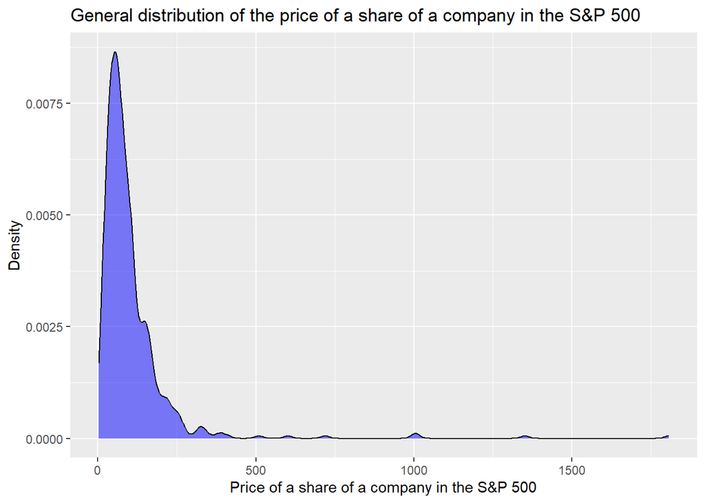

```r
ggplot (data = cleaned_financial_data)+
  geom_density (aes(x = Price), color ="black", fill = "blue", alpha = 0.5)+
  ggtitle ("General distribution of the price of a share of a company in the S&P 500")+
  xlab ("Price of a share of a company in the S&P 500") + ylab ("Density")
```

We see in the plot above, that the price of the shares is distributed very one-sidedly, with most of the prices of the shares falling between 0 and around 300 US-dollars. As such, the distribution of the Price is highly skewed to the right, with only a very little proportion of the stocks of the S&P 500 costing more than 300$.

## 4.2 Investigation of Binary Variables:

### 4.2.1 Determinant 1: Positive EBITDA

From the bar plot below we can see that most companies in the S&P 500 index list have positive Earnings, which is approximately 86.73% of the total.

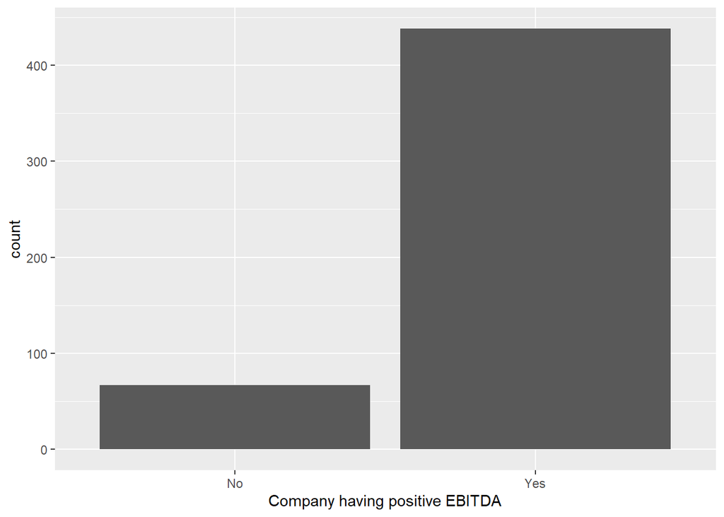

```r
ggplot (data = cleaned_financial_data)+
  geom_bar (aes(x=PositiveEBITDA))+
  xlab("Company having positive EBITDA")
```

```r
mean(cleaned_financial_data$PositiveEBITDA.Binary)
```

```
  [1] 0.8673267
```

In order to better observe the relationship of the presence of earnings of a company and the stock price we construct a box plot and density graphs for the corresponding variables.

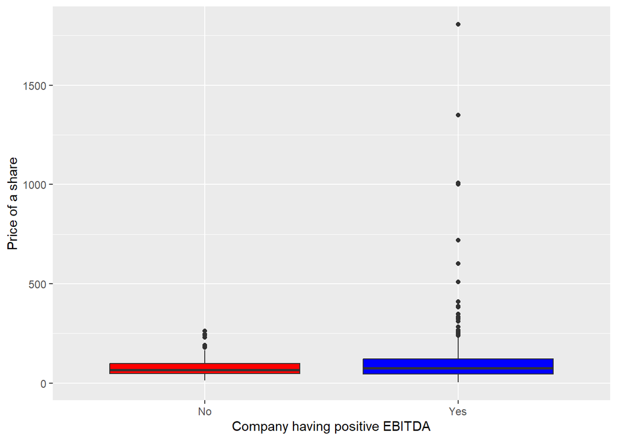

```r
ggplot (data = cleaned_financial_data)+
  geom_boxplot(aes(x = PositiveEBITDA, y = Price), fill = c("red", "blue"))+
  xlab("Company having positive EBITDA")+ ylab("Price of a share")
```

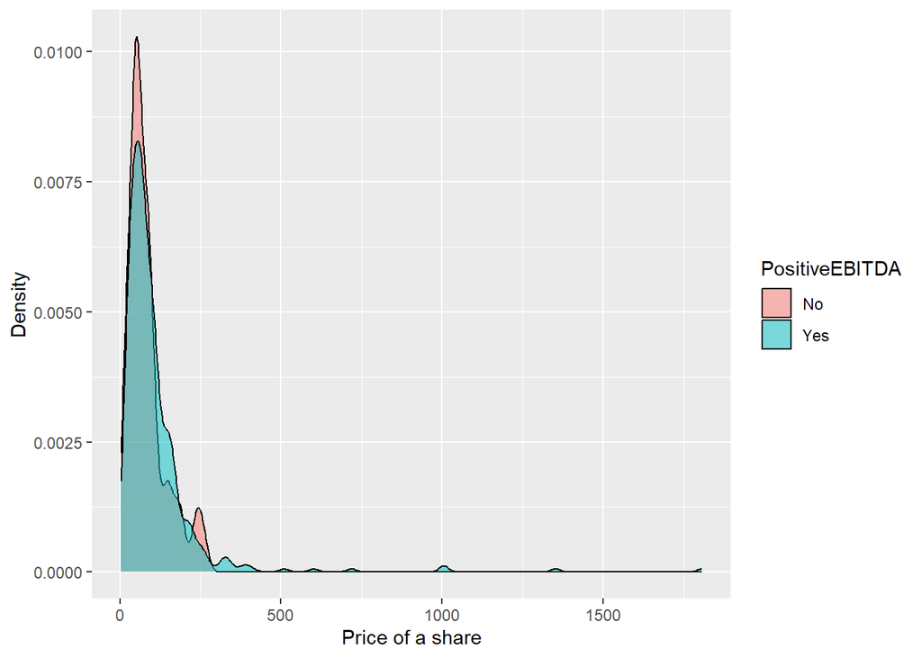

```r
ggplot (data = cleaned_financial_data)+
  geom_density(aes(x = Price, fill = PositiveEBITDA), alpha = 0.5)+
  xlab("Price of a share")+ ylab("Density")
```

The results do not show a significant difference in price for the firms with positive or non positive earnings. Most of the firms of both kinds are found in the 0 to 250 stock price range, while the firms with stock price higher than 300 show the trend of having positive earnings, even though they represent a small part of the data set.

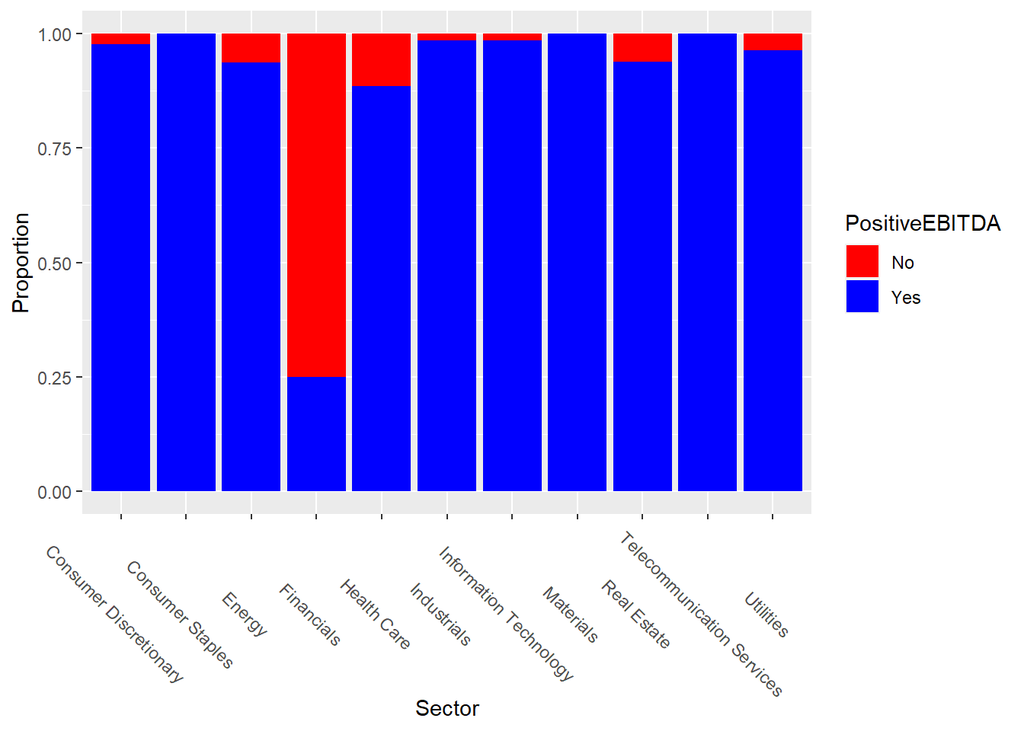

```r
ggplot(cleaned_financial_data, aes(x = Sector, fill = PositiveEBITDA)) +
  geom_bar(position = "fill") +
  labs(y = "Proportion")+
  scale_fill_manual( values = c( "red", "blue" ) ) +
  theme( axis.text.x = element_text( angle = -45 ) )
```

A T-test is going to be run in order to investigate whether firms with positive EBITDA have an effect on the stock price target variable.

```r
t.test(Price ~ PositiveEBITDA, data = cleaned_financial_data)
```

```
    Welch Two Sample t-test

  data:  Price by PositiveEBITDA
  t = -2.4945, df = 209.34, p-value = 0.01339
  alternative hypothesis: true difference in means between group No and group Yes is not equal to 0
  95 percent confidence interval:
   -44.323421  -5.192338
  sample estimates:
   mean in group No mean in group Yes
           82.35746         107.11534
```

From the t-test between the Price and the presence of Earnings of a company, with a p-value of 0.01339 lower than the significance level of 0.05 percent, we can conclude that the `PositiveEBITDA` has indeed a significant effect on the Price of stock.

### 4.2.2 Determinant 2: The paying of a dividend

First, let us examine the distribution of the variable “Dividend”.

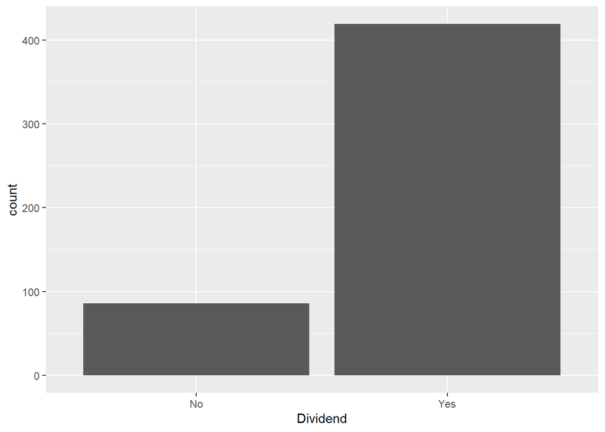

```r
ggplot (data = cleaned_financial_data)+
  geom_bar (aes(x=Dividend))
```

From the barplot, we can deduce that a big majority of the companies in the S&P 500 do pay dividends. To further examine whether a company that pays dividends affects the price of a share of that company, we are making use of a box plot and a density plot.

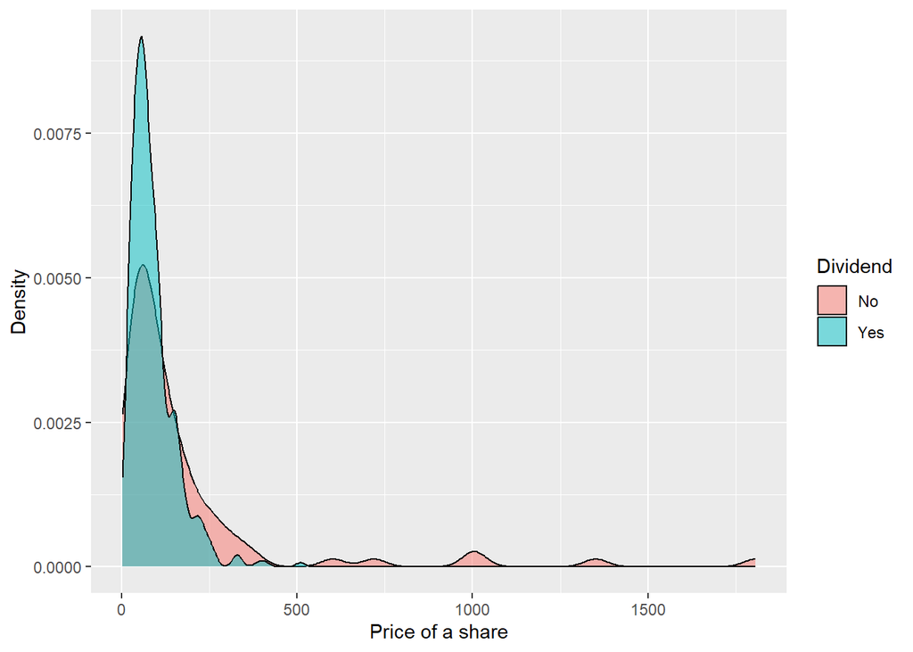

```r
ggplot (data = cleaned_financial_data)+
  geom_density(aes(x = Price, fill = Dividend), alpha = 0.5)+
  xlab("Price of a share")+ ylab("Density")
```

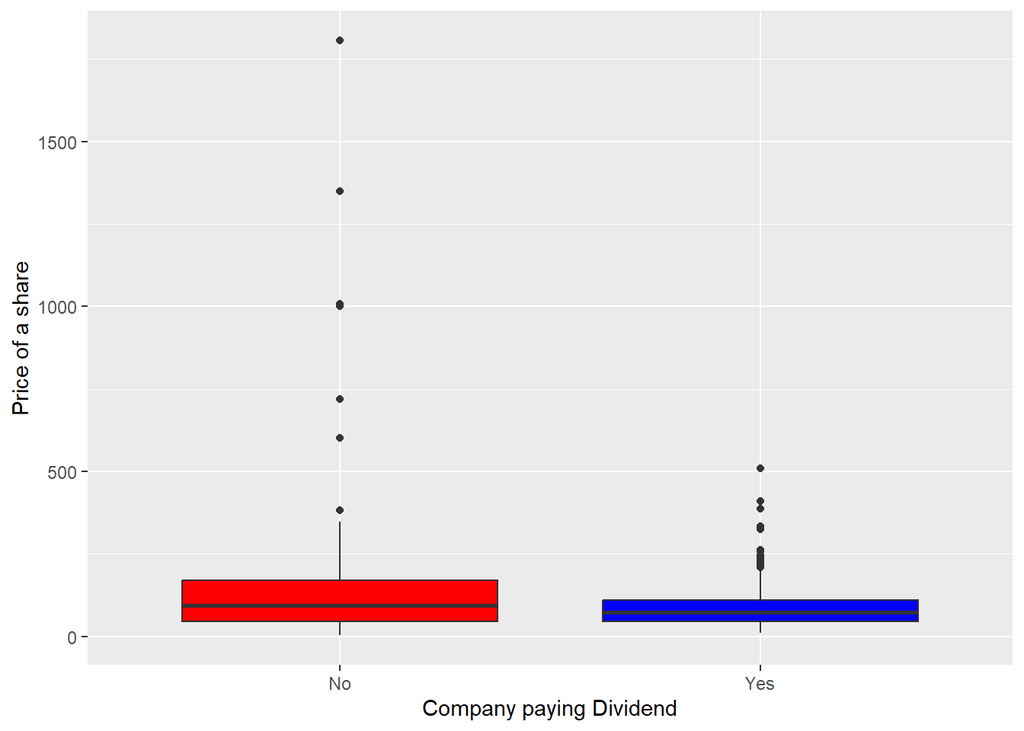

```r
ggplot (data = cleaned_financial_data)+
  geom_boxplot(aes(x = Dividend, y = Price), fill = c("red", "blue"))+
  xlab("Company paying Dividend")+ ylab("Price of a share")
```

The density plot demonstrates that while the majority of the companies in both groups fall within the price range of 0 US dollars to 500 US dollars, the companies that do not pay dividends are quite consistently more often found in the price range of over 200 dollars. This conclusion is somewhat supported by the box plot, as it demonstrates that the majority of the values of the companies that do not pay dividends are more spread out into the higher price regions than the companies that pay dividends, although the median of both groups is quite similar. But since these results suggest contradicting evidence to **H2a**, we further examine the relationship between the variables `Dividend` and `Price` with the help of a two-sample t-test.

```r
t.test(Price ~ Dividend, data = cleaned_financial_data)
```

```
    Welch Two Sample t-test

  data:  Price by Dividend
  t = 2.9236, df = 86.798, p-value = 0.004413
  alternative hypothesis: true difference in means between group No and group Yes is not equal to 0
  95 percent confidence interval:
    28.72388 150.73220
  sample estimates:
   mean in group No mean in group Yes
          178.27826          88.55021
```

The statistically significant results (at the .05 level) of the two sample t-test suggest that there is a statistically significant difference in the average prices in the two groups. This will be more thoroughly explored later during modeling.

## 4.3 Investigation of Numerical Variables:

Moving on to the numerical variables, a correlation plot and correlation panels are constructed to observe the effects of the variables with each other.

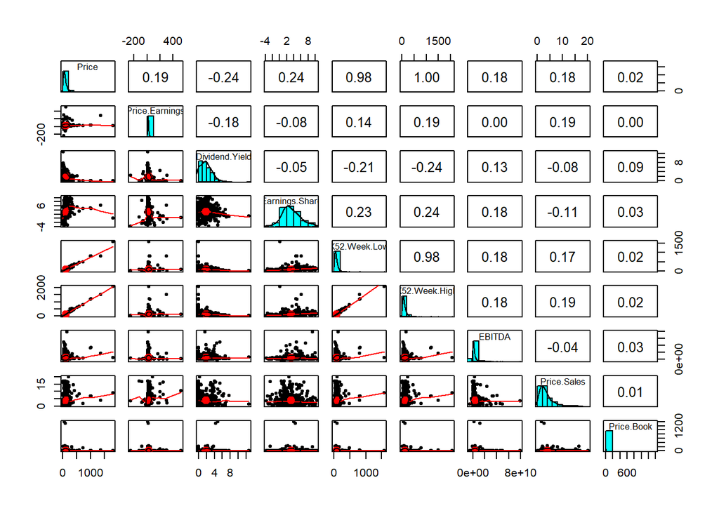

```r
variable_list = c( "Price","Price.Earnings","Dividend.Yield","Earnings.Share","X52.Week.Low","X52.Week.High","EBITDA","Price.Sales", "Price.Book")

pairs.panels( cleaned_financial_data[ , variable_list ] )
```

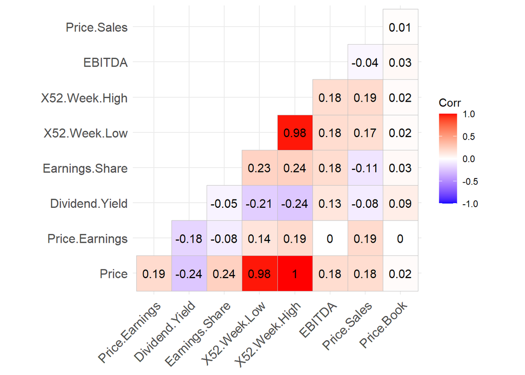

```r
cor_matrix = cor(cleaned_financial_data[, variable_list])

ggcorrplot(cor_matrix, type = "lower", lab = TRUE)
```

From the correlation table, it can be observed that most of the variables have low levels of correlation with each other, most of the numbers representing a lower than 0.25 deviation from 0. However, The X52.Week.Low and X52.Week.High variables have an almost perfect correlation of 0.98 which is not a surprising result, considering that in this data set they are used to represent a measure of the variance of the stock price. Furthermore in order not to overestimate the effect of the variance in the regression model, one of the variables shall be dropped, which will be the X52.Week.High due to the fact that even though it has a higher correlation with the target variable, the X52.Week.Low has smaller correlations with all the other explanatory variables in the data set.

Additionally, considering that the Binary variables in the data set describe a similar phenomena as the `Dividend.Yield` and `EBITDA` variables, we should do a corresponding Pearson correlation test for the binary variables.

```r
cor.test( cleaned_financial_data$Dividend.Yield, cleaned_financial_data$Dividend.Binary)
```

```
    Pearson's product-moment correlation

  data:  cleaned_financial_data$Dividend.Yield and cleaned_financial_data$Dividend.Binary
  t = 15.133, df = 503, p-value < 2.2e-16
  alternative hypothesis: true correlation is not equal to 0
  95 percent confidence interval:
   0.4962933 0.6164947
  sample estimates:
        cor
  0.5593271
```

```r
cor.test( cleaned_financial_data$EBITDA, cleaned_financial_data$PositiveEBITDA.Binary)
```

```
    Pearson's product-moment correlation

  data:  cleaned_financial_data$EBITDA and cleaned_financial_data$PositiveEBITDA.Binary
  t = 4.9257, df = 503, p-value = 1.142e-06
  alternative hypothesis: true correlation is not equal to 0
  95 percent confidence interval:
   0.1296858 0.2962240
  sample estimates:
        cor
  0.2145135
```

From the results, the conclusion can be made that with a correlation of 0.5593271 for the Dividend and Dividend.Yield variables, if we don’t want to overestimate their effect on the target variables in some models, we should drop one of the variables. Whereas, the correlation test of the EBITDA with a result of 0.2145135 is not too different from the other correlations present in the previous correlation panels.

### 4.3.1 Determinant 3: EBITDA

```r
summary (cleaned_financial_data$EBITDA)
```

```
        Min.    1st Qu.     Median       Mean    3rd Qu.       Max.
  -5.067e+09  7.739e+08  1.614e+09  3.590e+09  3.693e+09  7.939e+10
```

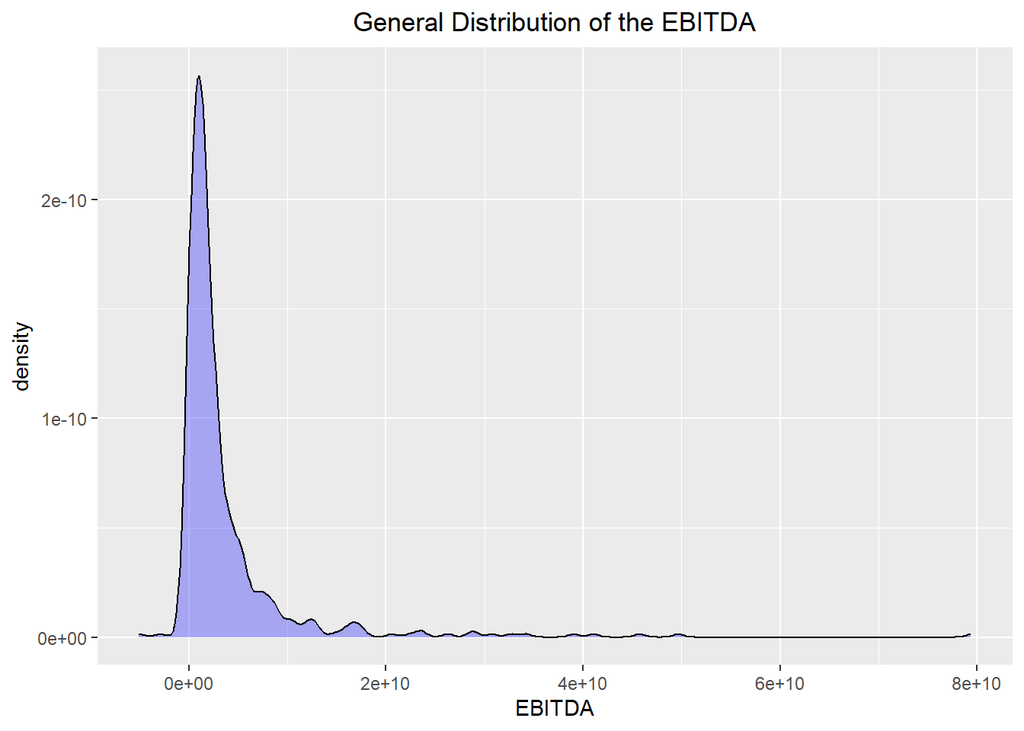

```r
ggplot (data = cleaned_financial_data)+
  geom_density (aes(x = EBITDA), color = "black", fill = "blue", alpha = 0.3)+
  ggtitle ("General Distribution of the EBITDA")+
  theme (plot.title = element_text(hjust = 0.5))+
  xlab("EBITDA")
```

In order to see the relationship between the `EBITDA` and the `Price` we create a scatterplot.

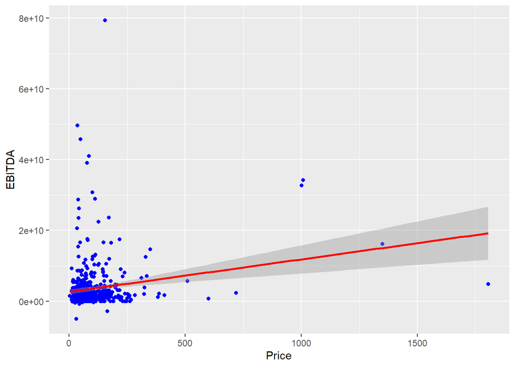

```r
ggplot(data= cleaned_financial_data, aes(x= Price, y=EBITDA))+
  geom_point(color="blue")+
  geom_smooth(method = "lm", color = "red")
```

Here we can notice a weak positive relationship between the variables, which might be disproportionately be affected by the positive EBITDA outliers. In order to test the significance of the EBITDA variable effect on the stock price in a linear model, a simple regression is run.

```r
Price_EBITDA_lm <- lm(Price ~ EBITDA, data = cleaned_financial_data)
summary(Price_EBITDA_lm)
```

```
  Call:
  lm(formula = Price ~ EBITDA, data = cleaned_financial_data)

  Residuals:
      Min      1Q  Median      3Q     Max
  -231.49  -56.00  -27.95   18.09 1697.93

  Coefficients:
               Estimate Std. Error t value Pr(>|t|)
  (Intercept) 9.111e+01  6.653e+00  13.694  < 2e-16 ***
  EBITDA      3.544e-09  8.619e-10   4.112 4.59e-05 ***
  ---
  Signif. codes:  0 '***' 0.001 '**' 0.01 '*' 0.05 '.' 0.1 ' ' 1

  Residual standard error: 132.4 on 503 degrees of freedom
  Multiple R-squared:  0.03252, Adjusted R-squared:  0.03059
  F-statistic:  16.9 on 1 and 503 DF,  p-value: 4.589e-05
```

With a p-value of 4.59e-05 we can conclude that the EBITDA has a significant effect on the target Price variable. However, from the value of the Adjusted R-squared only 0.03059 of the variability in the price variable is explained.

### 4.3.2 Determinant 4: Price-to-Sales Ratio

In order to investigate the Price.Sales variable we report the summary and plot its density and box plot graphs.

```r
summary (cleaned_financial_data$Price.Sales)
```

```
     Min. 1st Qu.  Median    Mean 3rd Qu.    Max.
   0.1532  1.6295  2.8964  3.9417  4.7038 20.0943
```

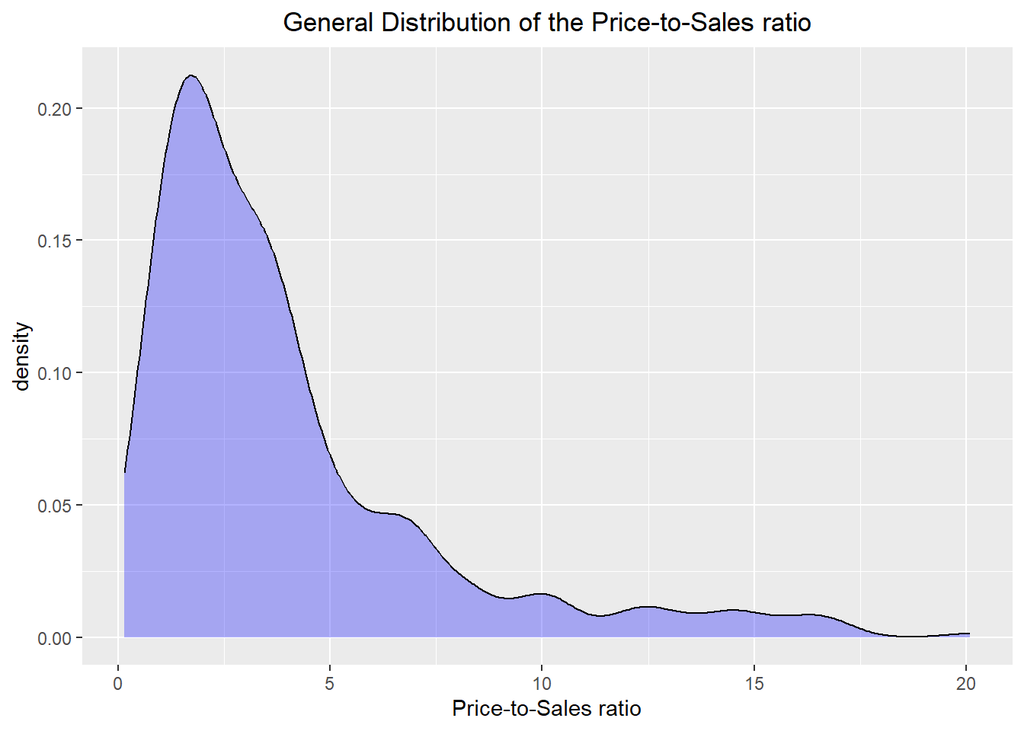

```r
ggplot (data = cleaned_financial_data)+
  geom_density (aes(x = Price.Sales), color = "black", fill = "blue", alpha = 0.3)+
  ggtitle ("General Distribution of the Price-to-Sales ratio")+
  theme (plot.title = element_text(hjust = 0.5))+
  xlab("Price-to-Sales ratio")
```

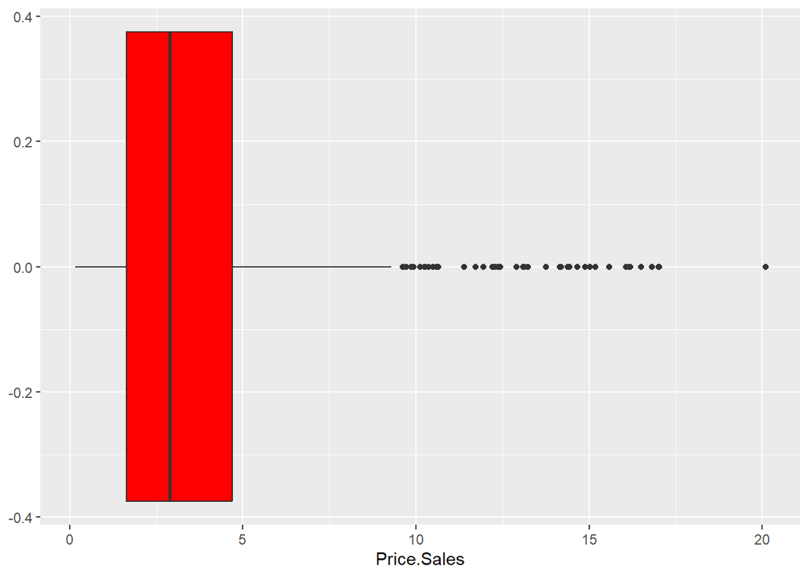

```r
ggplot (data = cleaned_financial_data)+
  geom_boxplot(aes(x = Price.Sales), fill = c("red"))
```

The Price-to-Sales of the data firms has a mean value of 3.9417, ranging from 0.1532 to 20.0943. From the visual plots we can conclude that the data is still skewed to the right, with the outliers being located at the values of the Price.Sales variable higher than 8, which however, are not as high on a magnitude level as the outliers of the previous numeric variables.

In order to see the relationship between the Price.Sales variable and the target Price, we will plot a scatter plot and run a regression to test the significance of the former’s variable effect.

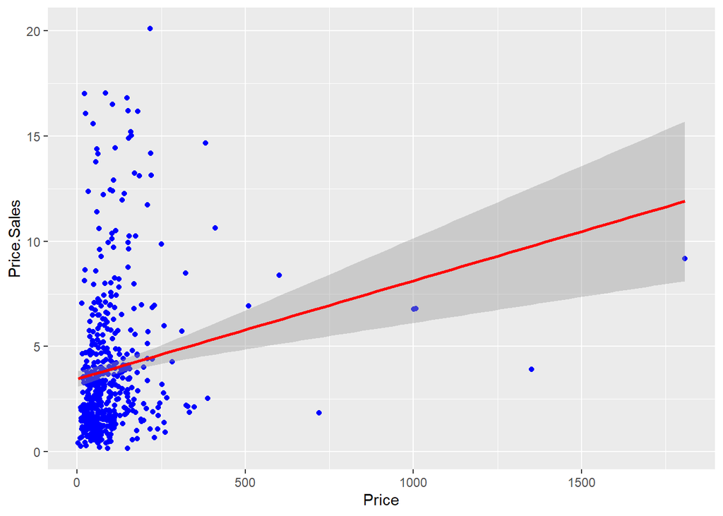

```r
ggplot(data= cleaned_financial_data, aes(x= Price, y=Price.Sales))+
  geom_point(color="blue")+
  geom_smooth(method = "lm", color = "red")
```

```r
Price_Price.Sales_lm <- lm(Price ~ Price.Sales, data = cleaned_financial_data)
summary(Price_Price.Sales_lm)
```

```
  Call:
  lm(formula = Price ~ Price.Sales, data = cleaned_financial_data)

  Residuals:
      Min      1Q  Median      3Q     Max
  -174.38  -53.21  -26.80   14.31 1665.29

  Coefficients:
              Estimate Std. Error t value Pr(>|t|)
  (Intercept)   76.017      8.931   8.512  < 2e-16 ***
  Price.Sales    7.056      1.703   4.142 4.03e-05 ***
  ---
  Signif. codes:  0 '***' 0.001 '**' 0.01 '*' 0.05 '.' 0.1 ' ' 1

  Residual standard error: 132.3 on 503 degrees of freedom
  Multiple R-squared:  0.03299, Adjusted R-squared:  0.03107
  F-statistic: 17.16 on 1 and 503 DF,  p-value: 4.033e-05
```

With a p-value of 4.03e-05 we can conclude that the Price.Sales has a significant effect on the target Price variable. However, from the value of the Adjusted R-squared only 0.03107 of the variability in the price variable is explained.

### 4.3.3 Determinant 5: Price-to-Book Ratio

In order to investigate the Price-to-Book variable we first report the summary and plot its density and box plot graphs.

```r
summary (cleaned_financial_data$Price.Book)
```

```
  Imputed Values:

  [1] 9.10 1.16 3.06 9.73 1.35 2.55 5.75 2.26
```

```
     Min. 1st Qu.  Median    Mean 3rd Qu.    Max.
     0.51    2.02    3.40   14.29    6.11 1403.38
```

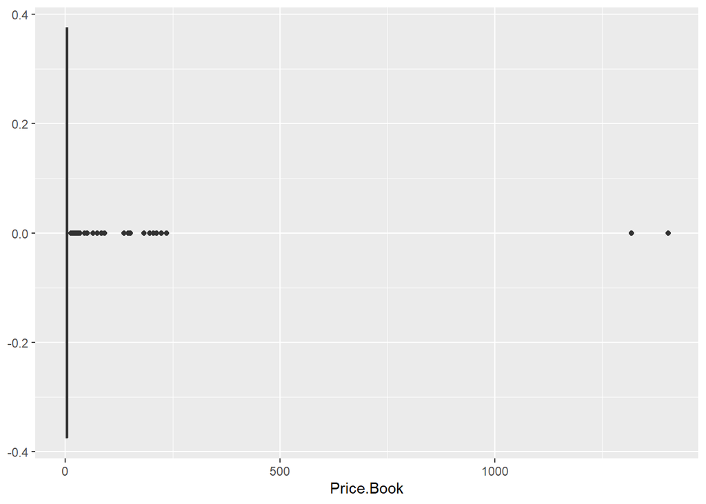

```r
ggplot (data = cleaned_financial_data)+
  geom_boxplot(aes(x = Price.Book), fill = c("red"))
```

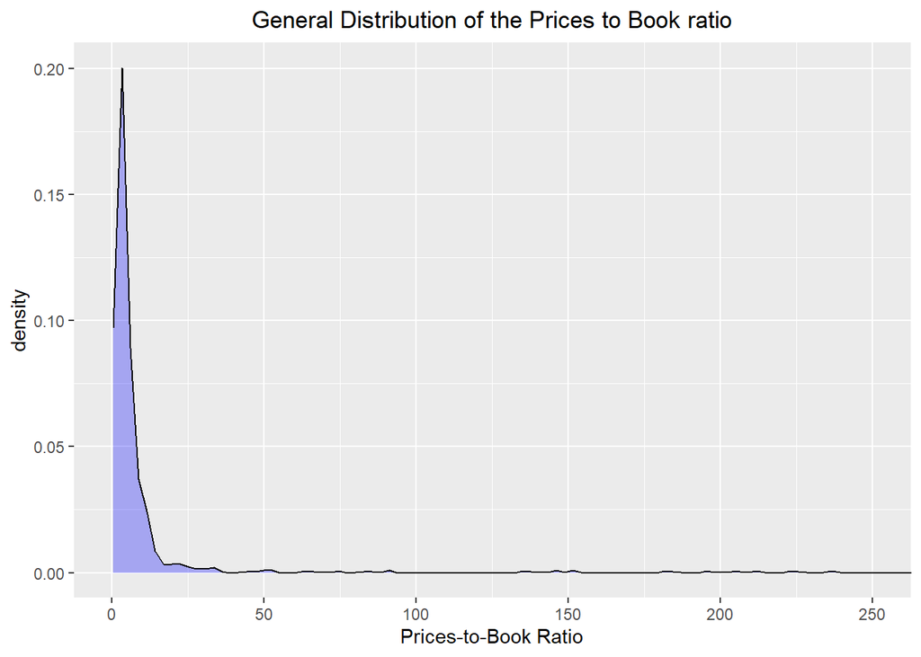

```r
ggplot (data = cleaned_financial_data)+
  geom_density (aes(x = Price.Book), color = "black", fill = "blue", alpha = 0.3)+
  ggtitle ("General Distribution of the Prices to Book ratio")+
  coord_cartesian( xlim = c( 0, 250 ) )+
  theme (plot.title = element_text(hjust = 0.5))+
  xlab("Prices-to-Book Ratio")
```

From the above density plot we notice that most of the data is still heavily skewed to the right with most of it being lower than 25. Too see the relationship between the Price.Book and the Price target variable we will plot a scatterplot and run a linear regression to study its explanatory effect.

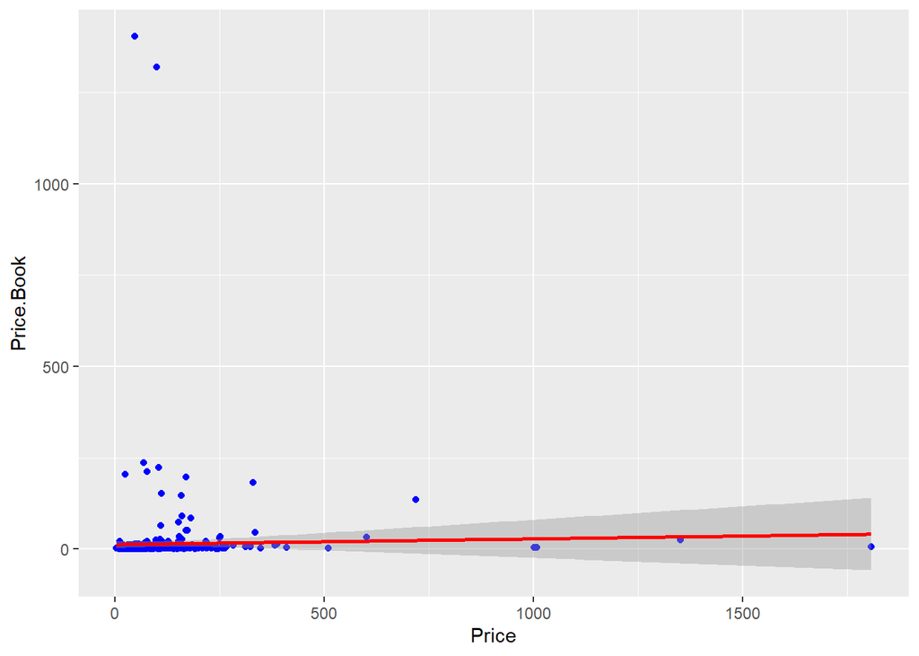

```r
ggplot(data= cleaned_financial_data, aes(x= Price, y=Price.Book))+
  geom_point(color="blue")+
  geom_smooth(method = "lm", color = "red")
```

```r
Price_Price.Book_lm <- lm(Price ~ Price.Book, data = cleaned_financial_data)
summary(Price_Price.Book_lm)
```

```
  Call:
  lm(formula = Price ~ Price.Book, data = cleaned_financial_data)

  Residuals:
      Min      1Q  Median      3Q     Max
  -105.63  -57.30  -30.07   12.91 1702.49

  Coefficients:
               Estimate Std. Error t value Pr(>|t|)
  (Intercept) 103.32060    6.06316   17.04   <2e-16 ***
  Price.Book    0.03568    0.06736    0.53    0.597
  ---
  Signif. codes:  0 '***' 0.001 '**' 0.01 '*' 0.05 '.' 0.1 ' ' 1

  Residual standard error: 134.5 on 503 degrees of freedom
  Multiple R-squared:  0.0005576,   Adjusted R-squared:  -0.001429
  F-statistic: 0.2806 on 1 and 503 DF,  p-value: 0.5965
```

### 4.3.4 Determinant 6: Dividend.Yield

First, let us explore the variable “Dividend.Yield” further, by examining the range and distribution of the variable.

```r
summary (cleaned_financial_data$Dividend.Yield)
```

```
     Min. 1st Qu.  Median    Mean 3rd Qu.    Max.
   0.0000  0.7948  1.7693  1.8960  2.7811 12.6612
```

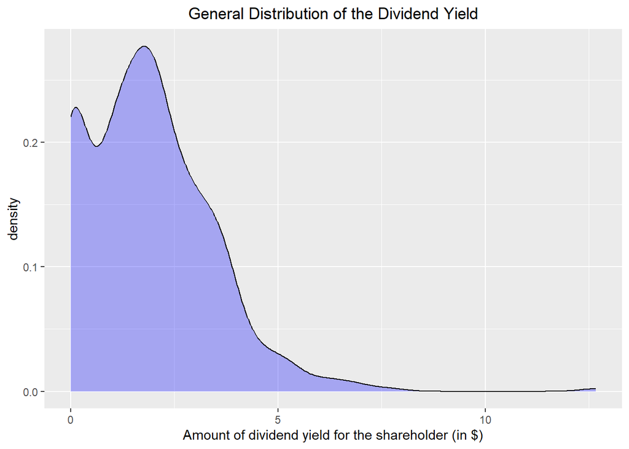

```r
ggplot (data = cleaned_financial_data)+
  geom_density (aes(x = Dividend.Yield), color = "black", fill = "blue", alpha = 0.3)+
  ggtitle ("General Distribution of the Dividend Yield")+
  theme (plot.title = element_text(hjust = 0.5))+
  xlab("Amount of dividend yield for the shareholder (in $)")
```

The amount of yield of a dividend ranges from 0 to 12.6612, with a mean yield of 1.8960. The distribution of the yield of a dividend is highly skewed to the right, with the majority of values falling between 0 and 5.

To further examine the relationship between the cash dividend that is paid to the shareholders of a stock and the price of a stock, a scatter plot is created.

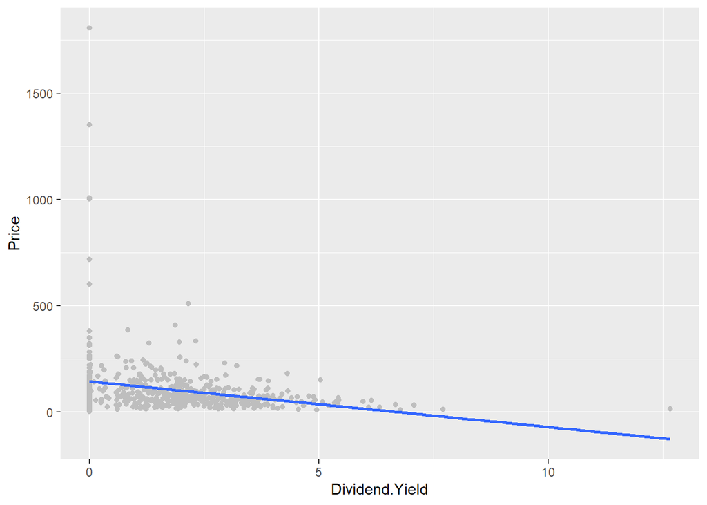

```r
ggplot (data = cleaned_financial_data, aes(x = Dividend.Yield, y = Price))+
  geom_point(color = "grey")+
  geom_smooth(method = "lm", se = FALSE)
```

The scatter plot displays a downwards trend, with a higher yield seemingly correlating with a lower price of a stock. As such, the scatter plot seems to suggest that there is indeed a relationship with perceived health. The displayed downwards trend would contradict our own expectations formulated in H2b. This trend has to be examined cautiously though, as the displayed line crosses the stock price 0 already at a yield of around 7, which would be an impossible value for the variable “Price” to attain.

```r
Price_Dividend.Yield_lm <- lm(Price ~ Dividend.Yield, data = cleaned_financial_data)
summary(Price_Dividend.Yield_lm)
```

```
  Call:
  lm(formula = Price ~ Dividend.Yield, data = cleaned_financial_data)

  Residuals:
      Min      1Q  Median      3Q     Max
  -141.57  -53.38  -20.52   24.89 1661.67

  Coefficients:
                 Estimate Std. Error t value Pr(>|t|)
  (Intercept)     144.390      9.224  15.653  < 2e-16 ***
  Dividend.Yield  -21.393      3.781  -5.658 2.57e-08 ***
  ---
  Signif. codes:  0 '***' 0.001 '**' 0.01 '*' 0.05 '.' 0.1 ' ' 1

  Residual standard error: 130.5 on 503 degrees of freedom
  Multiple R-squared:  0.05984, Adjusted R-squared:  0.05797
  F-statistic: 32.02 on 1 and 503 DF,  p-value: 2.568e-08
```

When testing the relationship with the help of a linear regression, we can see that the yield of a dividend indeed has a significant effect (at the .05 level) on the price of a stock. As such, we can conclude that the variable “Dividend.Yield” is a good predictor of the target variable “Price”.

### 4.3.5 Determinant 7: Price.Earnings

First, let us explore the variable “Price.Earnings” further, by examining the range.

```r
summary (cleaned_financial_data$Price.Earnings)
```

```
  Imputed Values:

  [1] 79.90 17.34
```

```
     Min. 1st Qu.  Median    Mean 3rd Qu.    Max.
  -251.53   15.35   19.45   24.90   25.76  520.15
```

To gain a deeper insight into the relation between the price-earnings ratio and the price of a stock, a scatterplot is created.

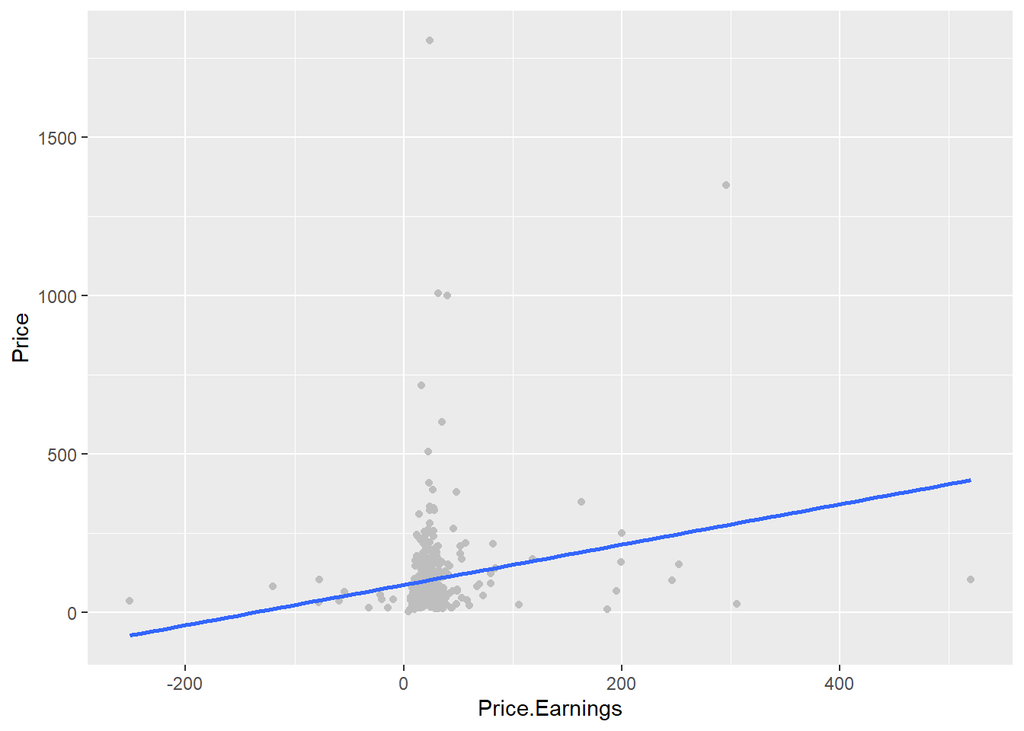

```r
ggplot (data = cleaned_financial_data, aes(x = Price.Earnings, y = Price))+
  geom_point(color = "grey")+
  geom_smooth(method = "lm", se = FALSE)
```

The scatter plot meanwhile seems to indicate that a higher value in the variable “Price.Earnings” correlates with a higher stock price. To further examine, whether the price-earnings ratio influences the stock price, a single linear regression model is created.

```r
Price_Price.Earnings_lm <- lm(Price ~ Price.Earnings, data = cleaned_financial_data)
summary(Price_Price.Earnings_lm)
```

```
  Call:
  lm(formula = Price ~ Price.Earnings, data = cleaned_financial_data)

  Residuals:
      Min      1Q  Median      3Q     Max
  -313.25  -53.60  -27.68   13.61 1702.64

  Coefficients:
                 Estimate Std. Error t value Pr(>|t|)
  (Intercept)     88.0692     6.8639  12.831  < 2e-16 ***
  Price.Earnings   0.6329     0.1426   4.439 1.11e-05 ***
  ---
  Signif. codes:  0 '***' 0.001 '**' 0.01 '*' 0.05 '.' 0.1 ' ' 1

  Residual standard error: 132 on 503 degrees of freedom
  Multiple R-squared:  0.03769, Adjusted R-squared:  0.03578
  F-statistic:  19.7 on 1 and 503 DF,  p-value: 1.114e-05
```

From the regression results, one can deduce that the price-earnings ratio has a significant effect (at the .05 level) on the target variable “Price”. The more nuanced effects of this predictor variable of the price of a S&P 500 stock are examined in the later modeling phase.

### 4.3.6 Determinant 8: Earnings per share

First, let us examine the range and distribution of the earnings per share.

```r
summary (cleaned_financial_data$Earnings.Share)
```

```
  Imputed Values:

  cleaned_financial_data$Earnings.Share
         n  missing distinct     Info     Mean      Gmd      .05      .10
        41        0       37        1    3.447    2.603     1.00     1.21
       .25      .50      .75      .90      .95
      1.59     2.81     5.39     6.64     7.31

  lowest : 0.46 0.88 1    1.21 1.26, highest: 6.64 7.14 7.31 8.51 9.38
```

```
     Min. 1st Qu.  Median    Mean 3rd Qu.    Max.
   -3.720   1.500   2.810   3.199   4.760  10.400
```

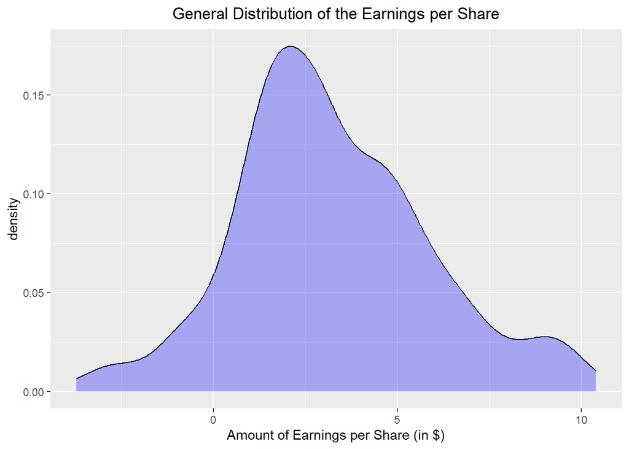

```r
ggplot (data = cleaned_financial_data)+
  geom_density (aes(x = Earnings.Share), color = "black", fill = "blue", alpha = 0.3)+
  ggtitle ("General Distribution of the Earnings per Share")+
  theme (plot.title = element_text(hjust = 0.5))+
  xlab("Amount of Earnings per Share (in $)")
```

The relationship between the earnings per share and the price of the stock is examined with the help of a scatter plot.

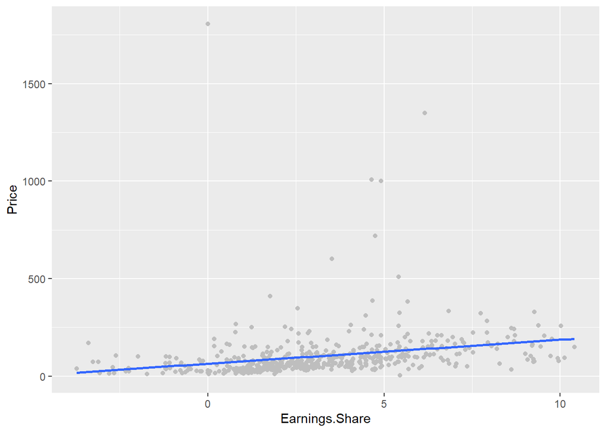

```r
ggplot (data = cleaned_financial_data, aes(x = Earnings.Share, y = Price))+
  geom_point(color = "grey")+
  geom_smooth(method = "lm", se = FALSE)
```

Following from the scatter plot, a slightly positive relationship of the `Earnings.Share` and the `Price` can be expected. This result would support the proposed hypothesis **H2c**. To examine whether the earnings per share actually significantly influence the price of a stock, a single linear regression model is created.

```r
Price_Earnings.Share_lm <- lm(Price ~ Earnings.Share, data = cleaned_financial_data)
summary(Price_Earnings.Share_lm)
```

```
  Call:
  lm(formula = Price ~ Earnings.Share, data = cleaned_financial_data)

  Residuals:
      Min      1Q  Median      3Q     Max
  -115.32  -49.20  -27.48   11.22 1732.38

  Coefficients:
                 Estimate Std. Error t value Pr(>|t|)
  (Intercept)      68.617      9.196   7.462 3.78e-13 ***
  Earnings.Share   11.006      2.219   4.961 9.62e-07 ***
  ---
  Signif. codes:  0 '***' 0.001 '**' 0.01 '*' 0.05 '.' 0.1 ' ' 1

  Residual standard error: 131.4 on 503 degrees of freedom
  Multiple R-squared:  0.04665, Adjusted R-squared:  0.04475
  F-statistic: 24.61 on 1 and 503 DF,  p-value: 9.616e-07
```

As a result of the linear regression results, we can confidently conclude that the variable `Earnings.Share` has a significant effect (at the .05 level) on the price of a S&P 500 stock. As such, the variable is deemed to be a good predictor variable for the modeling phase.

## 4.4 Additional variables of interest

### 4.4.1 Sector

To examine whether the sector in which a S&P 500 company operates influences the price of a share of the company, a box plot is created.

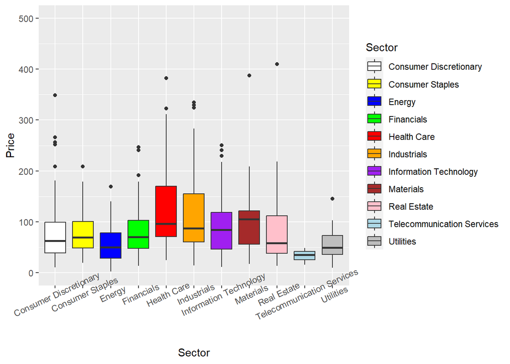

```r
sector_colors <- c("white", "yellow", "blue", "green", "red", "orange", "purple", "brown", "pink", "lightblue", "grey")


ggplot(data = cleaned_financial_data) +
  geom_boxplot(aes(x = Sector, y = Price, fill = Sector)) +
  theme(axis.text.x = element_text(angle = 25)) +
  scale_fill_manual(values = sector_colors) +
  ylim(0, 500)
```

As evident in the box plot, the stock prices of the companies can drastically differ between the financial sectors. Consequently, this box plot provides contradictory evidence to the **H2d**. To further examine, whether the financial sector in which a company operates has an effect on the stock price an ANOVA is used.

```r
anova_sec_price = aov(Price ~ Sector, data = cleaned_financial_data)
print (summary(anova_sec_price))
```

```
               Df  Sum Sq Mean Sq F value Pr(>F)
  Sector       10  303235   30324   1.701 0.0775 .
  Residuals   494 8804442   17823
  ---
  Signif. codes:  0 '***' 0.001 '**' 0.01 '*' 0.05 '.' 0.1 ' ' 1
```

The results of the Analysis of Variance show that there are no statistically significant differences (at the .05 level) between the different financial sectors of the S&P 500 companies and the stock prices of the companies. As such, we can conclude that we have found support for the Hypothesis, that the sector of the companies have no effect on the stock price.

# 5 Data preparation

In this stage, the dataset will be prepared for the modeling section. Here, the **cleaned_financial_data** dataset is partitioned randomly into two groups: train set (80%) and test set (20%). Here, the `partition()` function is used from the `liver` package, by inputting a random seed beforehand:

```r
set.seed( 6 )

data_sets = partition( data = cleaned_financial_data, prob = c( 0.8, 0.2 ) )

train_set = data_sets $ part1
test_set  = data_sets $ part2

actual_test  = test_set $ Price
```

Since the target variable of the model is numeric, based on the random partition, we will validate the partition by testing whether the variance of the variable `Price` differs in both groups of train and test. In order to do this, an F-test is conducted with a significance level of 5%. Based on this, following hypotheses are stated:

$$\bigg\{
\begin{matrix}
H_0: \sigma^2_1 = \sigma^2_2\\
H_a: \sigma^2_1 \neq \sigma^2_2
\end{matrix}$$

In this sense, the null hypothesis states that the variance of the variable `Price` does not differ for train and test groups. On the other hand, the alternative hypothesis claims that for both groups, the variance differs.

```r
var.test(train_set $ Price, test_set $ Price, alternative = "two.sided")
```

```
    F test to compare two variances

  data:  train_set$Price and test_set$Price
  F = 1.0323, num df = 395, denom df = 108, p-value = 0.8598
  alternative hypothesis: true ratio of variances is not equal to 1
  95 percent confidence interval:
   0.7530215 1.3782364
  sample estimates:
  ratio of variances
            1.032256
```

It can be observed from the above output that the test outcome has an F value of 1.0323 and a p-value of 0.8598. It can be seen that since the p-value is larger than the significance level of 5% (0.8598 > 0.05), we do not reject the null hypothesis. This means that we do not have sufficient evidence to claim that the variance for the ‘Price’ differs between train and test group. To validate the partition in terms of population mean a Two Sample t-test is conducted to observe whether the sample means for two group differ. In this sense, the following hypotheses are created:

$$\bigg\{
\begin{matrix}
H_0: \mu_1 = \mu_2\\
H_a: \mu_1 \neq \mu_2
\end{matrix}$$

In this sense, the null hypothesis states that the mean of the variable `Price` does not differ for train and test groups. On the other hand, the alternative hypothesis claims that for both groups, the mean differs.

```r
t.test(train_set $ Price, test_set $ Price, var.equal=TRUE)
```

```
    Two Sample t-test

  data:  train_set$Price and test_set$Price
  t = 0.56118, df = 503, p-value = 0.5749
  alternative hypothesis: true difference in means is not equal to 0
  95 percent confidence interval:
   -20.42141  36.75187
  sample estimates:
  mean of x mean of y
   105.5930   97.4278
```

It can be observed from the above output that the test outcome has an t-value of 0.56118 and a p-value of 0.5749 with a degrees of freedom of 503. It can be seen that since the p-value is larger than the significance level of 5% (0.5749 > 0.05), we do not reject the null hypothesis. This means that we do not have sufficient evidence to claim that the mean for the ‘Price’ differs between train and test group. The above interpretations for the statistical tests indicate that the partition for the target variable `Price` is valid.

# 6 Modeling

Considering the theoretical framework and outputs of the Exploratory Data Analysis (EDA), out of the 13 predictors in the dataset, the following variables are the ones that are detected to have an influence on the target variable and deemed to be important: `Price.Earnings`, `Dividend.Yield`, `Earnings.Share`, `EBITDA`, `PositiveEBITDA`, `Price.Sales`, `Price.Book` and `Dividend`. Given the variables and data partitioning, different algorithms will be utilized to determine the effects of financial information on price.

## 6.1 Multiple Linear Regression for All Variables

In order to conduct a multiple regression analysis, following model will be used:
$$\hat{y} = \beta_0 + \beta_1
X_1 + \beta_2 X_2 + \beta_3 X_3 + \beta_4 X_4 + \beta X_5 + \beta_6 X_6
+ \beta_7 X_7 + \beta_8 X_8$$

The model will be created by calling the built-in `lm()` function in R and use `summary()` function to analyze the significance and the coefficients of the variables.

```r
formula_financial = Price ~ Price.Earnings + Dividend.Yield + Earnings.Share + EBITDA + PositiveEBITDA + Price.Sales + Price.Book + Dividend
formula_financial_regress = lm( formula_financial, data = train_set )
summary(formula_financial_regress)
```

```
  Call:
  lm(formula = formula_financial, data = train_set)

  Residuals:
      Min      1Q  Median      3Q     Max
  -292.47  -35.29  -11.86   17.81 1651.11

  Coefficients:
                      Estimate Std. Error t value Pr(>|t|)
  (Intercept)        7.502e+01  2.629e+01   2.854  0.00456 **
  Price.Earnings     4.995e-01  1.537e-01   3.251  0.00125 **
  Dividend.Yield    -1.441e+01  5.127e+00  -2.810  0.00520 **
  Earnings.Share     1.115e+01  2.454e+00   4.543 7.41e-06 ***
  EBITDA             2.690e-09  9.021e-10   2.982  0.00305 **
  PositiveEBITDAYes  9.478e-01  1.955e+01   0.048  0.96137
  Price.Sales        5.298e+00  1.848e+00   2.867  0.00437 **
  Price.Book         2.845e-02  8.379e-02   0.340  0.73439
  DividendYes       -2.903e+01  2.078e+01  -1.397  0.16316
  ---
  Signif. codes:  0 '***' 0.001 '**' 0.01 '*' 0.05 '.' 0.1 ' ' 1

  Residual standard error: 123.8 on 387 degrees of freedom
  Multiple R-squared:  0.1758,  Adjusted R-squared:  0.1588
  F-statistic: 10.32 on 8 and 387 DF,  p-value: 4.104e-13
```

Based on the above output of the regression model, it can be observed that the variables `Price.Earnings`, `Dividend.Yield`, `EBITDA`, `Price.Sales` are significant at $\alpha=0.01$ whereas the variable `Earnings.Share` show statistical significance at $\alpha=0.001$. Furthermore, the variables `PositiveEBITDA`, `Price.Book` and `Dividend` have no significance for the model at any levels. In this sense, the model has a residual standard error of 123.8 on 387 degrees of freedom and the adjusted R-square of the model is at 0.1588. These levels present that the model has a high standard deviation of the residuals in which it is not representative for estimations due to high divergence. Furthermore, a low R-squared is indicative for a low goodness of fit meaning that the model does not fit the sample data accurately where only 15.88% of the target variable variance is explained.

The stepwise regression is run to obtain more robust outputs using iteration and observe all independent variables to select the most optimal ones.

## 6.2 Stepwise Regression Model

In order to create a stepwise regression formula, the built-in function `step()` is used by passing a direction option of ’both’to specify both forward and backward selection. As the iteration process is complete, `summary()` function is used once again to observe the details of the model.

```r
reg_step = step( formula_financial_regress, direction = "both" )
```

```
  Start:  AIC=3825.25
  Price ~ Price.Earnings + Dividend.Yield + Earnings.Share + EBITDA +
      PositiveEBITDA + Price.Sales + Price.Book + Dividend

                   Df Sum of Sq     RSS    AIC
  - PositiveEBITDA  1        36 5930852 3823.2
  - Price.Book      1      1767 5932583 3823.4
  - Dividend        1     29917 5960733 3825.2
  <none>                        5930816 3825.2
  - Dividend.Yield  1    121037 6051853 3831.2
  - Price.Sales     1    125944 6056760 3831.6
  - EBITDA          1    136267 6067084 3832.2
  - Price.Earnings  1    161957 6092774 3833.9
  - Earnings.Share  1    316322 6247138 3843.8

  Step:  AIC=3823.25
  Price ~ Price.Earnings + Dividend.Yield + Earnings.Share + EBITDA +
      Price.Sales + Price.Book + Dividend

                   Df Sum of Sq     RSS    AIC
  - Price.Book      1      1781 5932633 3821.4
  <none>                        5930852 3823.2
  - Dividend        1     30094 5960946 3823.3
  + PositiveEBITDA  1        36 5930816 3825.2
  - Dividend.Yield  1    121132 6051985 3829.3
  - Price.Sales     1    126481 6057334 3829.6
  - EBITDA          1    143505 6074357 3830.7
  - Price.Earnings  1    163608 6094460 3832.0
  - Earnings.Share  1    317196 6248049 3841.9

  Step:  AIC=3821.37
  Price ~ Price.Earnings + Dividend.Yield + Earnings.Share + EBITDA +
      Price.Sales + Dividend

                   Df Sum of Sq     RSS    AIC
  <none>                        5932633 3821.4
  - Dividend        1     30893 5963526 3821.4
  + Price.Book      1      1781 5930852 3823.2
  + PositiveEBITDA  1        50 5932583 3823.4
  - Dividend.Yield  1    119535 6052167 3827.3
  - Price.Sales     1    127494 6060127 3827.8
  - EBITDA          1    143114 6075747 3828.8
  - Price.Earnings  1    163599 6096232 3830.1
  - Earnings.Share  1    318319 6250951 3840.1
```

```r
summary(reg_step)
```

```
  Call:
  lm(formula = Price ~ Price.Earnings + Dividend.Yield + Earnings.Share +
      EBITDA + Price.Sales + Dividend, data = train_set)

  Residuals:
      Min      1Q  Median      3Q     Max
  -292.91  -35.52  -11.68   17.81 1650.93

  Coefficients:
                   Estimate Std. Error t value Pr(>|t|)
  (Intercept)     7.608e+01  2.037e+01   3.735 0.000216 ***
  Price.Earnings  5.001e-01  1.527e-01   3.275 0.001150 **
  Dividend.Yield -1.425e+01  5.091e+00  -2.800 0.005371 **
  Earnings.Share  1.116e+01  2.443e+00   4.569  6.6e-06 ***
  EBITDA          2.695e-09  8.799e-10   3.063 0.002341 **
  Price.Sales     5.321e+00  1.840e+00   2.891 0.004052 **
  DividendYes    -2.943e+01  2.068e+01  -1.423 0.155466
  ---
  Signif. codes:  0 '***' 0.001 '**' 0.01 '*' 0.05 '.' 0.1 ' ' 1

  Residual standard error: 123.5 on 389 degrees of freedom
  Multiple R-squared:  0.1756,  Adjusted R-squared:  0.1628
  F-statistic: 13.81 on 6 and 389 DF,  p-value: 3.063e-14
```

Based on the above output of the stepwise regression, it can be observed that the variable `Dividend` is still not significant at any levels even though it is included, the variables `Price.Sales`, `EBITDA`, `Dividend.Yield` and `Price.Earnings` are significant at $\alpha=0.01$ and the rest of the variables `Earnings.Share` is significant at $\alpha=0.001$. Furthermore, the model has an improved residual standard error of 123.5 and a slightly better adjusted R-squared value of 0.1628. In this sense, the predictions of the regression model differ from the actual values by 123.5. It is essential to note that even though this model explains only the 16.28% of the deviations in the target variable, since all explanatory variables are significant but one, the regression is a robust prediction model.

```r
formula_final = Price ~ Price.Earnings + Dividend.Yield + Earnings.Share + EBITDA + Price.Sales + Dividend
reg_final = lm(formula_final, data = train_set)
summary(reg_final)
```

```
  Call:
  lm(formula = formula_final, data = train_set)

  Residuals:
      Min      1Q  Median      3Q     Max
  -292.91  -35.52  -11.68   17.81 1650.93

  Coefficients:
                   Estimate Std. Error t value Pr(>|t|)
  (Intercept)     7.608e+01  2.037e+01   3.735 0.000216 ***
  Price.Earnings  5.001e-01  1.527e-01   3.275 0.001150 **
  Dividend.Yield -1.425e+01  5.091e+00  -2.800 0.005371 **
  Earnings.Share  1.116e+01  2.443e+00   4.569  6.6e-06 ***
  EBITDA          2.695e-09  8.799e-10   3.063 0.002341 **
  Price.Sales     5.321e+00  1.840e+00   2.891 0.004052 **
  DividendYes    -2.943e+01  2.068e+01  -1.423 0.155466
  ---
  Signif. codes:  0 '***' 0.001 '**' 0.01 '*' 0.05 '.' 0.1 ' ' 1

  Residual standard error: 123.5 on 389 degrees of freedom
  Multiple R-squared:  0.1756,  Adjusted R-squared:  0.1628
  F-statistic: 13.81 on 6 and 389 DF,  p-value: 3.063e-14
```

Therefore, the final regression model is: Price = 7.608e+01 + (5.001e-01) * Price.Earnings - (1.425e+01) * Dividend.Yield + (1.116e+01) * Earnings.Share + (2.695e-09) * EBITDA + (5.321e+00) * Price.Sales - (2.943e+01) * Dividend

As the true value of EBITDA is enormous, the small coefficient of the variable translate into a significant effect on the stock price. Thus, these coefficients indicate a predictive equation as follows: Price = 76.08 + 0.5001 * Price.Earnings - 14.25 * Dividend.Yield + 11.16 * Earnings.Share + 2.695 * 10$^-9$ * EBITDA + 5.321 * Price.Sales - 29.43 * Dividend

## 6.3 Regression Model Verification

After the model is created, it is important to check whether it satisfies the assumptions and requirements of the modeling section. In this sense, the `plot()` function will be used

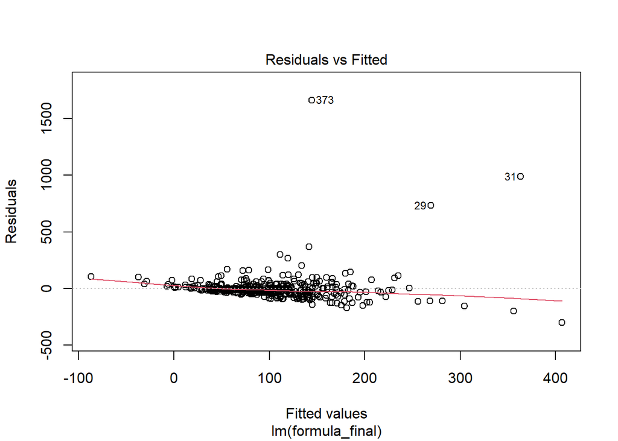

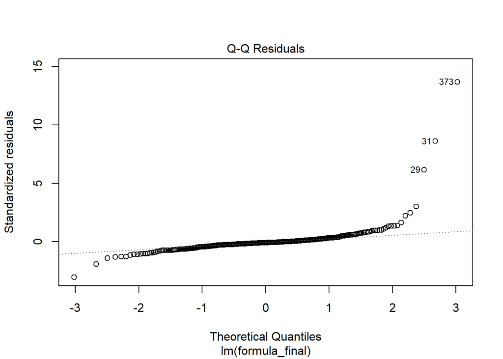

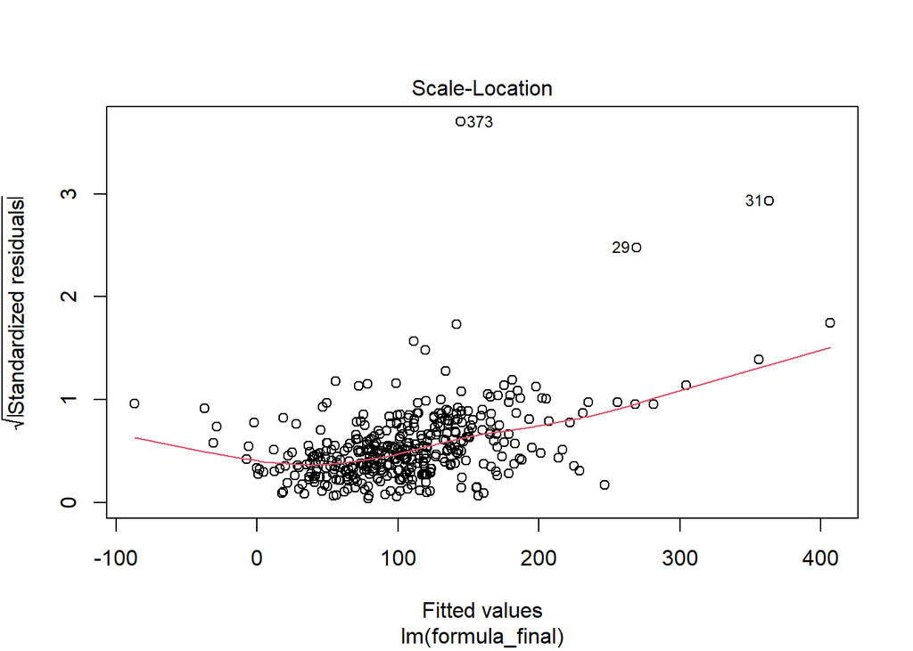

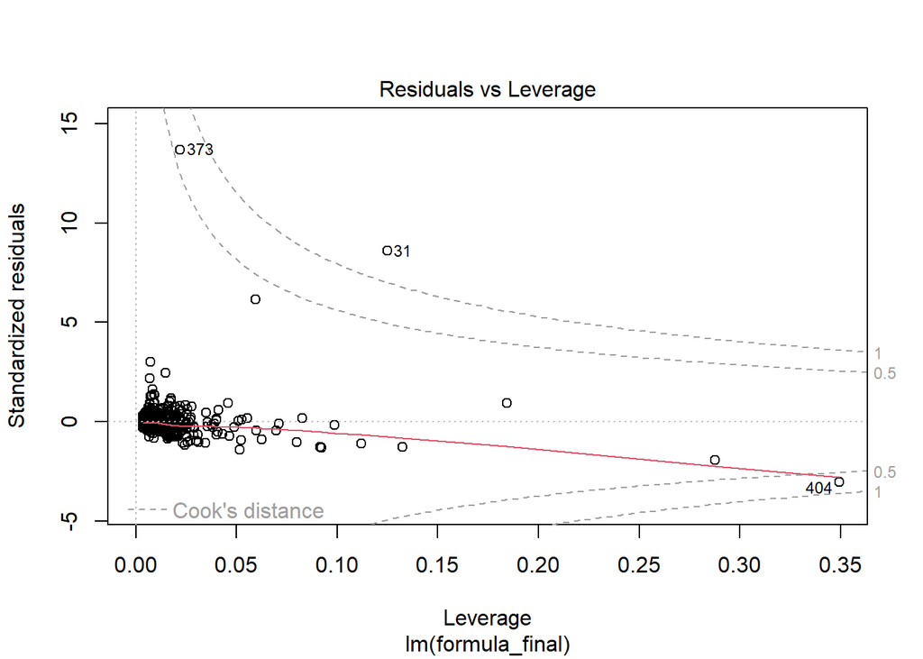

```r
plot(reg_final)
```